# Econometria III Aula 3

Mestrado Profissional em Administração

Prof. Dr. Washington Santos da Silva

26/10/2026

## Richard Feynman

> “Aprendi muito cedo a diferença entre saber o nome de alguma coisa e conhecer essa coisa.”

— Richard Feynman, *What Do You Care What Other People Think?* (1988, tradução livre).

## Programação da aula

### Aula anterior

- Fundamentos: endogeneidade, consistência e viés de variável omitida
- Modelo de efeitos aleatórios: formulação e estimação
- Estimando modelos de efeitos fixos e de efeitos aleatórios com R
- Teste de Hausman

### Hoje

- Inferência em modelos para dados em painel
  - **Inferência convencional:** fundamentos e limitações
  - **Dependência dentro das unidades:** correlação intraclasse e consequências para a inferência
  - **Inferência robusta em painel:** testes de dependência, matrizes de covariância robustas e aplicações em R

Inferência convencional: fundamentos e limites

## Coeficientes estimados e incerteza

Nas Aulas 1 e 2, aprendemos a formular, estimar e interpretar os modelos de **efeitos fixos (EF)** e **efeitos aleatórios (EA)**.

$$\widehat{\boldsymbol{\beta}}_{EF}
\qquad\text{e}\qquad
\widehat{\boldsymbol{\beta}}_{EA}$$

Cada método fornece **estimativas pontuais dos coeficientes** do modelo.

**Nova questão:** como quantificar a incerteza (erros-padrão) associada aos coeficientes estimados e avaliar hipóteses sobre os parâmetros do modelo?

## Inferência

### Testes e precisão das estimativas

**Testar hipóteses**

- Avaliar hipóteses sobre os parâmetros do modelo.
- Exemplo: testar $H_0:\beta_j=0$.

**Quantificar a precisão**

- Estimar os erros-padrão dos coeficientes.
- Construir intervalos de confiança para os parâmetros.

Ambas as finalidades exigem avaliar a variabilidade amostral dos estimadores.

## Mesma estimativa, inferências diferentes

Considere uma estimativa hipotética $\hat\beta=0{,}30$ e o teste bilateral $H_0:\beta=0$. Compare dois procedimentos para estimar o erro-padrão do mesmo coeficiente:

| Resultado | Procedimento A | Procedimento B |
| --- | --- | --- |
| Coeficiente $\hat\beta$ | 0,30 | 0,30 |
| Erro-padrão estimado | 0,10 | 0,20 |
| Estatística $\hat\beta/\widehat{EP}(\hat\beta)$ | 3,0 | 1,5 |
| IC de 95% (aprox.) | [0,10; 0,50] | [−0,09; 0,69] |

Ao nível de 5%, o procedimento A rejeita $H_0$, enquanto B não rejeita. A estimativa pontual é a mesma, a diferença nos erros-padrão estimados altera a conclusão inferencial.

## Hipóteses sobre os erros de MQO agrupado

O exemplo anterior mostrou como os erros-padrão afetam a inferência. Para compreender sua construção, começamos pelo **MQO agrupado**, como caso de referência:

$$\mathbf y=X\boldsymbol\beta+\boldsymbol\varepsilon.$$

**Condição sobre as regressoras:** $X$ deve ter **posto completo** (variação suficiente e ausência de colinearidade perfeita).

- $E(\boldsymbol\varepsilon\mid X)=\mathbf 0$: **exogeneidade estrita** — os erros têm esperança condicional nula, dadas as regressoras de todos os períodos.
- $\operatorname{Var}(\varepsilon_{it}\mid X)=\sigma^2$: **homocedasticidade condicional** — mesma variância dos erros para todas as unidades e períodos.
- $\operatorname{Cov}(\varepsilon_{it},\varepsilon_{js}\mid X)=0$, para $(i,t)\neq(j,s)$: **ausência de correlação condicional**, entre erros de observações distintas, inclusive de períodos da mesma unidade.

As duas últimas hipóteses caracterizam os **erros esféricos**:

$$\operatorname{Var}(\boldsymbol\varepsilon\mid X)
=\begin{pmatrix}
\sigma^2 & 0 & \cdots\\
0 & \sigma^2 & \cdots\\
\vdots & \vdots & \ddots
\end{pmatrix}
=\sigma^2I_n.$$

## Construção dos erros-padrão convencionais

**Objetivo:** estimar os erros-padrão dos coeficientes de MQO, sob as hipóteses convencionais sobre os erros. **Como chegaremos ao estimador dos erros-padrão?**

1. **Deduzir a matriz de covariância do estimador.** Partiremos da expressão do estimador de MQO e utilizaremos a hipótese de **erros esféricos** para demonstrar que:

   $$\operatorname{Var}(\hat{\boldsymbol\beta}_{MQO}\mid X)
   =\sigma^2(X'X)^{-1}.$$
2. **Estimar a variância dos erros.** Partiremos do estimador pelo **método dos momentos**, $SQR/n$, e utilizaremos a matriz $M_X$ e o operador traço para demonstrar seu viés e justificar a correção:

   $$\hat\sigma^2=\frac{SQR}{n-k}.$$
3. **Construir o estimador dos erros-padrão convencionais.** Substituiremos $\sigma^2$ por $\hat\sigma^2$ na matriz de covariância e calcularemos a **raiz quadrada dos elementos da diagonal**.

## Decomposição do estimador de MQO

Considere o modelo linear $\mathbf y=X\boldsymbol\beta+\boldsymbol\varepsilon$, com $X$ de posto completo de colunas.

**1. Substituindo o modelo na definição do estimador de MQO:**

$$\hat{\boldsymbol\beta}_{MQO}
=(X'X)^{-1}X'\mathbf y
=(X'X)^{-1}X'(X\boldsymbol\beta+\boldsymbol\varepsilon).$$

**2. Aplicando a distributividade e utilizando $(X'X)^{-1}(X'X)=I_k$:**

$$\begin{aligned}
\hat{\boldsymbol\beta}_{MQO}
&=(X'X)^{-1}(X'X)\boldsymbol\beta
+(X'X)^{-1}X'\boldsymbol\varepsilon\\[5pt]
&=\boldsymbol\beta+(X'X)^{-1}X'\boldsymbol\varepsilon.
\end{aligned}$$

**Erro de estimação:**

$$\boxed{
\hat{\boldsymbol\beta}_{MQO}-\boldsymbol\beta
=(X'X)^{-1}X'\boldsymbol\varepsilon
}$$

Condicionalmente a $X$, o estimador é aleatório porque depende dos erros do modelo.

## Matriz de covariância do estimador de MQO

Da decomposição anterior, defina $A=(X'X)^{-1}X'$. Assim,

$$\hat{\boldsymbol\beta}_{MQO}
=\boldsymbol\beta+A\boldsymbol\varepsilon.$$

**1. Aplicando a propriedade da covariância de transformações lineares:**

Como $A$ é constante condicionalmente a $X$,

$$\begin{aligned}
\operatorname{Var}(\hat{\boldsymbol\beta}_{MQO}\mid X)
&=\operatorname{Var}(\boldsymbol\beta+A\boldsymbol\varepsilon\mid X)\\[5pt]
&=A\operatorname{Var}(\boldsymbol\varepsilon\mid X)A'.
\end{aligned}$$

**2. Assumindo a hipótese de erros esféricos e simplificando:**

$$\begin{aligned}
\operatorname{Var}(\hat{\boldsymbol\beta}_{MQO}\mid X)
&=A(\sigma^2I)A'\\[5pt]
&=\sigma^2(X'X)^{-1}(X'X)(X'X)^{-1}\\[5pt]
&=\boxed{\sigma^2(X'X)^{-1}}.
\end{aligned}$$

## Representação matricial dos resíduos de MQO

A matriz de covariância do estimador de MQO depende da variância desconhecida dos erros, $\sigma^2$. Para estimá-la, partimos dos **resíduos de MQO**.

**1. Substituindo o estimador de MQO na definição dos resíduos:**

$$\begin{aligned}
\hat{\boldsymbol\varepsilon}
&=\mathbf y-X\hat{\boldsymbol\beta}_{MQO}
=\mathbf y-X(X'X)^{-1}X'\mathbf y\\[5pt]
&=\left[I_n-X(X'X)^{-1}X'\right]\mathbf y
=M_X\mathbf y.
\end{aligned}$$

Na segunda linha, usamos $\mathbf y=I_n\mathbf y$ para colocar $\mathbf y$ em evidência. Definimos $M_X=I_n-X(X'X)^{-1}X'$, em que $I_n$ é a matriz identidade de ordem $n$.

**2. Relacionando os resíduos aos erros do modelo:**

Como $(X'X)^{-1}(X'X)=I_k$, temos: $M_XX=X-X(X'X)^{-1}(X'X)=X-X=0$

Substituindo $\mathbf y=X\boldsymbol\beta+\boldsymbol\varepsilon$:

$$\begin{aligned}
\hat{\boldsymbol\varepsilon}
&=M_X\mathbf y=M_X(X\boldsymbol\beta+\boldsymbol\varepsilon)\\[5pt]
&=(M_XX)\boldsymbol\beta+M_X\boldsymbol\varepsilon
=\boxed{M_X\boldsymbol\varepsilon}.
\end{aligned}$$

**Interpretação:** $M_X$ elimina o componente $X\boldsymbol\beta$; os resíduos são uma transformação dos erros, não os próprios erros.

## Representação matricial dos resíduos de MQO

No slide anterior, demonstramos que $\hat{\boldsymbol\varepsilon}=M_X\boldsymbol\varepsilon$. Para expressar a **SQR** em função dos erros, utilizamos duas propriedades de $M_X$:

- **Simetria:** $M_X'=M_X$, pois $(X'X)^{-1}$ é simétrica.
- **Idempotência:** $M_X^2=M_X$. Como $M_XX=0$, temos:

$$M_X^2=M_X-(M_XX)(X'X)^{-1}X'=M_X.$$

**Aplicando essas propriedades à SQR:**

$$\begin{aligned}
SQR
&=\hat{\boldsymbol\varepsilon}'\hat{\boldsymbol\varepsilon}
=(M_X\boldsymbol\varepsilon)'(M_X\boldsymbol\varepsilon)\\[5pt]
&=\boldsymbol\varepsilon'M_X'M_X\boldsymbol\varepsilon
=\boxed{\boldsymbol\varepsilon'M_X\boldsymbol\varepsilon}.
\end{aligned}$$

A SQR é calculada com os resíduos; a última expressão será utilizada para obter sua **esperança condicional**.

## Esperança condicional da SQR

Hansen parte do **estimador pelo método dos momentos**, $SQR/n$. Para investigar seu viés, começamos calculando $E(SQR\mid X)$, utilizando o **operador traço**.

**1. Reescrevendo a SQR como um traço:**

O **traço** de uma matriz quadrada é a soma de seus elementos diagonais. Para um escalar, é o próprio valor. Além disso, $\operatorname{tr}(AB)=\operatorname{tr}(BA)$.

$$\begin{aligned}
SQR
&=\boldsymbol\varepsilon'M_X\boldsymbol\varepsilon
=\operatorname{tr}(\boldsymbol\varepsilon'M_X\boldsymbol\varepsilon)\\[5pt]
&=\operatorname{tr}(M_X\boldsymbol\varepsilon\boldsymbol\varepsilon').
\end{aligned}$$

**2. Obtendo a esperança condicional de $\boldsymbol\varepsilon\boldsymbol\varepsilon'$:**

Pela **exogeneidade estrita**, $E(\boldsymbol\varepsilon\mid X)=\mathbf 0$; sob **erros esféricos**, $\operatorname{Var}(\boldsymbol\varepsilon\mid X)=\sigma^2I_n$. Portanto,

$$\begin{aligned}
E(\boldsymbol\varepsilon\boldsymbol\varepsilon'\mid X)
&=\operatorname{Var}(\boldsymbol\varepsilon\mid X)
+E(\boldsymbol\varepsilon\mid X)E(\boldsymbol\varepsilon\mid X)'\\[5pt]
&=\sigma^2I_n.
\end{aligned}$$

## Esperança condicional da SQR

A **SQR é calculada com os resíduos**: $SQR=\hat{\boldsymbol\varepsilon}'\hat{\boldsymbol\varepsilon}$. No slide anterior, demonstramos que também podemos escrevê-la como $SQR=\operatorname{tr}(M_X\boldsymbol\varepsilon\boldsymbol\varepsilon')$.

Como $M_X$ depende apenas de $X$, é constante condicionalmente a $X$. Pela linearidade da esperança condicional e do traço:

$$\begin{aligned}
E(SQR\mid X)
&=E\left[\operatorname{tr}(M_X\boldsymbol\varepsilon\boldsymbol\varepsilon')\mid X\right]\\[5pt]
&=\operatorname{tr}\left(M_XE(\boldsymbol\varepsilon\boldsymbol\varepsilon'\mid X)\right)\\[5pt]
&=\operatorname{tr}(M_X\sigma^2I_n)
=\boxed{\sigma^2\operatorname{tr}(M_X)}.
\end{aligned}$$

**Para completar a demonstração, resta calcular $\operatorname{tr}(M_X)$.**

## Por que dividir a SQR por $n-k$?

Obtivemos $E(SQR\mid X)=\sigma^2\operatorname{tr}(M_X)$. Para avançar, precisamos calcular $\operatorname{tr}(M_X)$.

**1. Calculando o traço da matriz $M_X$:**

Como $M_X=I_n-X(X'X)^{-1}X'$, pela linearidade do traço:

$$\begin{aligned}
\operatorname{tr}(M_X)
&=\operatorname{tr}(I_n)
-\operatorname{tr}\left[X(X'X)^{-1}X'\right]\\[5pt]
&=n-\operatorname{tr}\left[(X'X)^{-1}X'X\right]\\[5pt]
&=n-\operatorname{tr}(I_k)=\boxed{n-k}.
\end{aligned}$$

Na segunda linha, utilizamos a **propriedade do traço**, $\operatorname{tr}(AB)=\operatorname{tr}(BA)$. Na última, $(X'X)^{-1}X'X=I_k$.

**Interpretação:** $n$ é o número de observações e $k$ o número de coeficientes estimados (incluindo o intercepto, quando presente). Assim, $n-k$ corresponde aos **graus de liberdade do resíduo**.

## Por que dividir a SQR por $n-k$?

**2. Por que dividir por $n$ produz viés?**

No slide anterior, obtivemos $\operatorname{tr}(M_X)=n-k$. Portanto,

$$\begin{aligned}
E(SQR\mid X)
&=\sigma^2\operatorname{tr}(M_X)=(n-k)\sigma^2,\\[5pt]
E\left(\frac{SQR}{n}\,\middle|\,X\right)
&=\frac{n-k}{n}\sigma^2<\sigma^2.
\end{aligned}$$

Assim, $SQR/n$ apresenta **viés condicional negativo**: em média, subestima $\sigma^2$.

**3. Como eliminar esse viés?** Dividimos a SQR pelos **$n-k$ graus de liberdade dos resíduos**:

$$\boxed{
\hat\sigma^2
=\frac{SQR}{n-k}
=\frac{\hat{\boldsymbol\varepsilon}'\hat{\boldsymbol\varepsilon}}{n-k}
}$$

Verificando sua esperança condicional:

$$E(\hat\sigma^2\mid X)
=\frac{E(SQR\mid X)}{n-k}
=\sigma^2.$$

Para $n>k$, sob **exogeneidade estrita e erros esféricos**, $\hat\sigma^2$ é **condicionalmente não viesado**.

## Matriz de covariância estimada

Sob **erros esféricos**, obtivemos $\operatorname{Var}(\hat{\boldsymbol\beta}_{MQO}\mid X)=\sigma^2(X'X)^{-1}$. Como $\sigma^2$ é desconhecida, substituímos por $\hat\sigma^2=SQR/(n-k)$:

$$\widehat V_{\hat{\boldsymbol\beta}}
=\hat\sigma^2(X'X)^{-1}.$$

**O que representam os elementos dessa matriz?**

Para um modelo com dois coeficientes, defina $C=(X'X)^{-1}=[c_{ij}]$:

$$\widehat V_{\hat{\boldsymbol\beta}}
=
\begin{pmatrix}
\hat\sigma^2 c_{11} & \hat\sigma^2 c_{12}\\
\hat\sigma^2 c_{21} & \hat\sigma^2 c_{22}
\end{pmatrix}
=
\begin{pmatrix}
\hat v_{11} & \hat v_{12}\\
\hat v_{21} & \hat v_{22}
\end{pmatrix}.$$

- **Diagonal:** variâncias estimadas dos coeficientes.
- **Fora da diagonal:** covariâncias estimadas entre os coeficientes.

## Erros-padrão convencionais

**Como obtemos os erros-padrão convencionais?**

Calculamos a raiz quadrada de cada elemento da diagonal:

$$\widehat{EP}(\hat\beta_j)
=\sqrt{\hat v_{jj}}
=\sqrt{\hat\sigma^2c_{jj}}
=\hat\sigma\sqrt{c_{jj}},
\qquad \hat\sigma=\sqrt{\hat\sigma^2}.$$

**Atenção:** se houver heterocedasticidade ou correlação entre os erros, esses erros-padrão podem ser viesados e inconsistentes.

## Heterocedasticidade e dependência dos erros em painel

| Fenômeno | Exemplo em dados em painel |
| --- | --- |
| **Heterocedasticidade** | A variância condicional dos erros difere entre empresas ou períodos. |
| **Dependência dentro da unidade** | Os erros de uma mesma empresa estão correlacionados ao longo do tempo. |
| **Dependência entre unidades (transversal)** | Choques macroeconômicos não controlados podem gerar erros correlacionados entre empresas. |

**Implicação:** esses fenômenos podem comprometer a inferência quando não são adequadamente considerados no cálculo dos erros-padrão.

## Corrigir a inferência não é corrigir a endogeneidade

**Problema de estimação**

Quando a **exogeneidade estrita** é violada, o estimador dos coeficientes ($\hat{\boldsymbol\beta}$) pode ser **inconsistente**, mesmo em amostras grandes.

**Problema de inferência**

Mesmo com um estimador consistente, uma matriz de covariância dos coeficientes estimada sob hipóteses inadequadas pode comprometer **erros-padrão, testes e intervalos de confiança**.

**Atenção:** erros-padrão robustos não corrigem a **endogeneidade**.

**Próximo bloco:** o que acontece com a inferência quando ignoramos a correlação dos erros dentro da mesma unidade?

Dependência dentro das unidades: correlação intraclasse e suas consequências

## Mesma empresa, erros potencialmente correlacionados

Considere um painel de empresas $i$, observadas em diferentes períodos $t$. Uma relação de interesse em Finanças é:

$$y_{it}=\beta_0+\beta_1x_{it}+v_{it},$$

em que $y_{it}$ representa **investimento/ativos** e $x_{it}$, **fluxo de caixa/ativos**.

Características não observadas da empresa, como práticas de gestão relativamente estáveis, podem afetar seu investimento em vários períodos.

**Os erros de observações de uma mesma empresa podem estar correlacionados ao longo do tempo.**

## Dependência dentro das unidades

### Etapas da análise

**Objetivo:** compreender como a correlação dos erros de uma mesma empresa pode afetar a precisão das estimativas (avaliada pelos erros-padrão) e a **validade da inferência**.

1. **Identificar e quantificar a dependência.** Utilizaremos o modelo de componentes do erro para explicar a correlação entre períodos da mesma empresa e deduzir a **correlação intraclasse**.
2. **Demonstrar as consequências para a precisão.** Examinaremos a variância da média dos erros e, em um caso simples de MQO agrupado, deduziremos o **fator de Moulton**.
3. **Compreender as implicações para a inferência.** Mostraremos como ignorar essa dependência pode comprometer **erros-padrão, testes de hipóteses e intervalos de confiança**.

## O componente compartilhado do erro

No modelo de componentes do erro, para dois períodos distintos da mesma empresa:

$$\begin{aligned}
v_{it}&=u_i+e_{it},\\[6pt]
v_{is}&=u_i+e_{is},\qquad t\neq s.
\end{aligned}$$

- $u_i$: **heterogeneidade individual não observada**, constante ao longo dos períodos analisados.
- $e_{it}$: **erro idiossincrático**, específico da empresa e do período.

O componente $u_i$ é **compartilhado pelas duas observações**. É essa característica que pode gerar correlação entre os erros compostos.

## A covariância surge do componente compartilhado

Sob as hipóteses convencionais, suponha:

- $\operatorname{Var}(u_i)=\sigma_u^2$;
- $\operatorname{Cov}(u_i,e_{it})=0$ em todos os períodos;
- $\operatorname{Cov}(e_{it},e_{is})=0$, para $t\neq s$.

Assim, a covariância entre dois erros compostos da mesma empresa é:

$$\begin{aligned}
\operatorname{Cov}(v_{it},v_{is})
&=\operatorname{Cov}(u_i+e_{it},u_i+e_{is})\\[5pt]
&=\operatorname{Var}(u_i)+\operatorname{Cov}(u_i,e_{is})\\
&\quad+\operatorname{Cov}(e_{it},u_i)
+\operatorname{Cov}(e_{it},e_{is})\\[5pt]
&=\sigma_u^2+0+0+0=\boxed{\sigma_u^2}.
\end{aligned}$$

**Mesmo sem autocorrelação em $e_{it}$**, os erros compostos de períodos distintos são correlacionados quando $\sigma_u^2>0$.

## De onde vem a correlação intraclasse?

Sob as mesmas hipóteses, com $\operatorname{Var}(e_{it})=\sigma_e^2$, a variância do erro composto é:

$$\begin{aligned}
\operatorname{Var}(v_{it})
&=\operatorname{Var}(u_i)+\operatorname{Var}(e_{it})\\
&=\sigma_u^2+\sigma_e^2.
\end{aligned}$$

Pela definição de correlação, para $t\neq s$:

$$\begin{aligned}
\rho_v
&=\frac{\operatorname{Cov}(v_{it},v_{is})}
{\sqrt{\operatorname{Var}(v_{it})\operatorname{Var}(v_{is})}}\\[7pt]
&=\frac{\sigma_u^2}
{\sqrt{(\sigma_u^2+\sigma_e^2)^2}}\\[7pt]
&=\boxed{\frac{\sigma_u^2}{\sigma_u^2+\sigma_e^2}}.
\end{aligned}$$

A **correlação intraclasse** mede a parcela da variância total do erro composto atribuível ao componente compartilhado $u_i$.

## O que a correlação intraclasse nos informa?

Na estrutura clássica de componentes do erro:

$$\rho_v=\frac{\sigma_u^2}{\sigma_u^2+\sigma_e^2},
\qquad 0\leq\rho_v\leq1.$$

**Se $\rho_v=0$**

A variância do componente compartilhado é nula: $\sigma_u^2=0$.

Não há correlação entre períodos por esse mecanismo.

**Se $\rho_v$ se aproxima de 1**

A variância do componente compartilhado domina a variância do erro composto.

Os erros dos diferentes períodos tornam-se muito semelhantes.

A correlação é **a mesma para qualquer par de períodos** da empresa, independentemente da distância temporal: uma estrutura de equicorrelação.

## A equicorrelação não esgota a dependência em painel

A estrutura anterior pressupõe ausência de autocorrelação no erro idiossincrático:

$$\operatorname{Cov}(e_{it},e_{is})=0,\qquad t\neq s.$$

Se permitirmos autocorrelação em $e_{it}$, mantendo a ausência de covariância entre $u_i$ e os erros idiossincráticos:

$$\boxed{
\operatorname{Cov}(v_{it},v_{is})
=\sigma_u^2+\operatorname{Cov}(e_{it},e_{is})
}$$

A covariância pode variar entre pares de períodos, deixando de apresentar a estrutura simples de equicorrelação.

**Distinção importante:** o modelo clássico de EA já contempla a correlação gerada por $u_i$.

A **dependência adicional não contemplada pelo modelo** pode tornar seus erros-padrão convencionais inadequados.

## Por que a dependência altera a precisão?

Para uma empresa $i$, observada em $T$ períodos, considere a **soma dos erros compostos**:

$$S_i=\sum_{t=1}^{T}v_{it}.$$

A variância dessa soma é:

$$\operatorname{Var}(S_i)
= \sum_{t=1}^{T}\operatorname{Var}(v_{it}) +2\sum_{t<s}\operatorname{Cov}(v_{it},v_{is}).$$

**Se os erros são correlacionados**, a variância inclui também as covariâncias entre os períodos.

Ignorar covariâncias positivas produz uma variância menor do que a verdadeira para essa soma.

## A dependência aumenta a variância da média

Considere a **média dos erros** de uma empresa:

$$\bar v_i=\frac{1}{T}\sum_{t=1}^{T}v_{it}.$$

Sob a estrutura de equicorrelação estudada, com $\operatorname{Var}(v_{it})=\sigma_v^2$ e $\operatorname{Cov}(v_{it},v_{is})=\rho_v\sigma_v^2$:

$$\begin{aligned}
\operatorname{Var}(\bar v_i)
&=\frac{1}{T^2}
\left[T\sigma_v^2+T(T-1)\rho_v\sigma_v^2\right]\\[6pt]
&=\boxed{\frac{\sigma_v^2}{T}
\left[1+(T-1)\rho_v\right]}.
\end{aligned}$$

Se os erros fossem independentes, teríamos apenas $\operatorname{Var}_0(\bar v_i)=\sigma_v^2/T$.

Com $\rho_v>0$, a média contém **menos informação independente** do que teríamos sob ausência de correlação.

## Uma regressora constante dentro de cada empresa

Para compreender o efeito sobre a variância de um **coeficiente de MQO**, considere:

$$y_{it}=\beta_0+\beta_1z_i+v_{it}.$$

A regressora $z_i$ é uma característica observável da empresa, **constante nos períodos analisados**, mas variável entre empresas.

Adotamos as seguintes hipóteses:

- $N$ empresas independentes, observadas nos mesmos $T$ períodos;
- $z_i$ tratado como fixo e exógeno em relação aos erros;
- variância $\sigma_v^2$ e correlação intraclasse $\rho_v$ constantes, também condicionalmente às regressoras.

Estimamos a regressão por **MQO agrupado**.

**Questão:** como a dependência dentro das empresas afeta a variância de $\hat\beta_1$?

## A inclinação depende das médias por empresa

Defina as médias:

$$\bar z=\frac{1}{N}\sum_{i=1}^{N}z_i,
\qquad
\bar v_i=\frac{1}{T}\sum_{t=1}^{T}v_{it}.$$

Na regressão simples com intercepto, podemos escrever:

$$\hat\beta_1-\beta_1
=\frac{\displaystyle\sum_{i=1}^{N}\sum_{t=1}^{T}
(z_i-\bar z)v_{it}}
{\displaystyle\sum_{i=1}^{N}\sum_{t=1}^{T}
(z_i-\bar z)^2}
=\frac{\displaystyle\sum_{i=1}^{N}
(z_i-\bar z)\bar v_i}
{\displaystyle\sum_{i=1}^{N}(z_i-\bar z)^2}.$$

Como $z_i$ não varia no tempo, os erros das $T$ observações entram no coeficiente estimado por meio da **média dos erros de cada empresa**.

## A dependência chega à variância do estimador

Defina $D=\sum_{i=1}^{N}(z_i-\bar z)^2$.

Como as empresas são independentes e a variância das médias é a mesma para todas elas:

$$\operatorname{Var}(\hat\beta_1\mid Z)
=\frac{\displaystyle\sum_{i=1}^{N}(z_i-\bar z)^2
\operatorname{Var}(\bar v_i\mid Z)}{D^2}
=\frac{\operatorname{Var}(\bar v_i\mid Z)}{D}.$$

Substituindo a variância da média obtida anteriormente:

$$\boxed{
\operatorname{Var}(\hat\beta_1\mid Z)
=\frac{\sigma_v^2}{TD}
\left[1+(T-1)\rho_v\right]
}$$

Se a correlação fosse ignorada, a fórmula convencional consideraria apenas:

$$\operatorname{Var}_0(\hat\beta_1\mid Z)
=\frac{\sigma_v^2}{TD}.$$

## O fator de Moulton

Comparando as duas variâncias teóricas:

$$\boxed{
\frac{\operatorname{Var}(\hat\beta_1\mid Z)}
{\operatorname{Var}_0(\hat\beta_1\mid Z)}
=1+(T-1)\rho_v
}$$

Na escala dos desvios-padrão, o multiplicador é:

$$\boxed{
M=\sqrt{1+(T-1)\rho_v}
}$$

Esse multiplicador é denominado **fator de Moulton** (Moulton, 1986).

- Se $\rho_v=0$, então $M=1$: não há inflação por esse mecanismo.
- Se $\rho_v>0$, então $M>1$: a dependência aumenta a variância do estimador $\hat\beta_1$ em relação à fórmula que pressupõe independência.

**Nota:** *Esse fator expressa uma razão teórica. Não determina exatamente a razão entre erros-padrão estimados em qualquer amostra.*

## Correlação pequena, grande efeito sobre a precisão

Considere empresas observadas **trimestralmente durante dez anos**:

$$T=40,\qquad \rho_v=0{,}05.$$

Mesmo com correlação intraclasse de apenas $0{,}05$:

$$\frac{\operatorname{Var}(\hat\beta_1)}
{\operatorname{Var}_0(\hat\beta_1)}
=1+(40-1)\times0{,}05
=\boxed{2{,}95}.$$

O fator de Moulton será:

$$M=\sqrt{2{,}95}\approx\boxed{1{,}72}.$$

**Interpretação:** sob as hipóteses do exemplo, o desvio-padrão teórico de $\hat\beta_1$ é aproximadamente **72% maior** do que aquele obtido pressupondo independência.

## Consequências para os testes de hipóteses

Para testar $H_0:\beta_1=\beta_{1,0}$, a estatística convencional é:

$$t_0=\frac{\hat\beta_1-\beta_{1,0}}
{\operatorname{EP}_0(\hat\beta_1)}.$$

Com um erro-padrão apropriado para a dependência:

$$t=\frac{\hat\beta_1-\beta_{1,0}}
{\operatorname{EP}(\hat\beta_1)}.$$

Para a mesma estimativa pontual:

$$\frac{|t_0|}{|t|}
=\frac{\operatorname{EP}(\hat\beta_1)}
{\operatorname{EP}_0(\hat\beta_1)}.$$

Quando os erros-padrão estimados refletem as respectivas variâncias teóricas, essa razão se aproxima do fator de Moulton.

**Ignorar a dependência pode produzir estatísticas $t$ exageradas e intervalos de confiança excessivamente estreitos.**

## O fator depende também da estrutura das regressoras

Sob hipóteses específicas, quando a regressora pode variar dentro dos grupos e seus tamanhos são diferentes, uma extensão aproximada do resultado é:

$$\boxed{
\frac{\operatorname{Var}(\hat\beta_1)}
{\operatorname{Var}_0(\hat\beta_1)}
\approx
1+\left[
\frac{\operatorname{Var}(m_i)}{\bar m}+\bar m-1
\right]\rho_z\rho_v
}$$

em que:

- $m_i$: número de observações da empresa $i$; $\bar m$: tamanho médio dos grupos;
- $\rho_z$: correlação intraclasse da regressora relevante;
- $\rho_v$: correlação intraclasse dos erros.

Com grupos de mesmo tamanho e regressora constante no grupo, temos $\rho_z=1$ e recuperamos o resultado anterior.

**A dependência dos erros não determina, isoladamente, a precisão de cada coeficiente estimado.**

## O fator de Moulton cresce com $T$ e $\rho_v$

No caso especial de **MQO agrupado**, com regressora constante por empresa:

$$M=\sqrt{1+(T-1)\rho_v}.$$

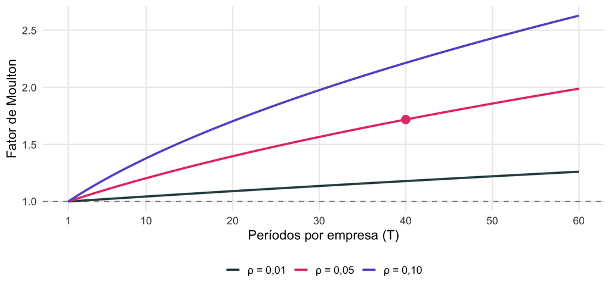

Figura 1: O fator de Moulton aumenta com o número de períodos por empresa ($T$) e a correlação intraclasse ($\rho_v$). O ponto destacado corresponde a $T=40$ e $\rho_v=0{,}05$, com $M\approx1{,}72$.

## Inferência robusta

fator de Moulton quantifica, sob hipóteses específicas, como a dependência dentro das empresas afeta a variabilidade de um estimador de MQO

Ele **não é um estimador geral de erros-padrão**.

Existem duas estratégias econométricas distintas:

**Modelar a dependência**

Especificar a estrutura de covariância dos erros e utilizá-la na estimação, como em GLS/FGLS.

**Robustecer a inferência**

Manter o estimador pontual e estimar sua matriz de covariância permitindo dependência dentro das empresas.

Os **erros-padrão robustos a agrupamentos** seguem a segunda estratégia, sob hipóteses apropriadas, incluindo independência entre empresas.

## Dependência intraclasse/intragrupo

### Principais conclusões

1. **Origem da dependência.** O componente individual compartilhado $u_i$ pode gerar **correlação entre os erros de uma mesma empresa**. A autocorrelação dos erros idiossincráticos pode produzir dependência adicional.
2. **Consequências para a precisão.** No caso especial de MQO agrupado estudado, a correlação intraclasse positiva **aumenta a variância do estimador $\hat\beta_1$**. O **fator de Moulton** quantifica esse efeito, cuja magnitude também depende do número de períodos e da estrutura das regressoras.
3. **Consequências para a inferência.** Ignorar a dependência relevante pode comprometer **erros-padrão, testes de hipóteses e intervalos de confiança**, mesmo quando os coeficientes são estimados consistentemente.

Inferência robusta em painel: matrizes e diagnósticos

## Inferência robusta em painel

### Etapas da análise

**Objetivo:** compreender como **estimar a incerteza dos coeficientes** quando os erros apresentam heterocedasticidade ou correlação, considerando as **hipóteses e limitações** dos procedimentos de inferência.

1. **Construir matrizes de covariância robustas.** Partiremos da matriz sanduíche para compreender os estimadores de **White** e **White–Arellano** e o papel do agrupamento por empresa.
2. **Aplicar a inferência robusta a efeitos fixos.** Com os dados `EmplUK`, utilizaremos o **teste de Wooldridge** para investigar a autocorrelação dos erros e calcularemos **erros-padrão, testes e intervalos de confiança** com agrupamento por empresa.
3. **Examinar a dependência entre empresas.** Utilizaremos o **teste CD de Pesaran**, estudaremos o método de **Driscoll–Kraay** e compararemos os resultados, considerando **as hipóteses e limitações de cada procedimento**.

## A matriz sanduíche

Sob **erros esféricos**, obtivemos para o MQO agrupado:

$$\operatorname{Var}(\hat{\boldsymbol\beta}_{MQO}\mid X)
=\sigma^2(X'X)^{-1}.$$

Essa expressão decorre da decomposição do estimador:

$$\hat{\boldsymbol\beta}_{MQO}-\boldsymbol\beta
=(X'X)^{-1}X'\boldsymbol\varepsilon.$$

Sem impor erros esféricos, aplicamos a mesma propriedade da variância, com $\Omega=\operatorname{Var}(\boldsymbol\varepsilon\mid X)$:

$$\boxed{
\operatorname{Var}(\hat{\boldsymbol\beta}_{MQO}\mid X)
=(X'X)^{-1}
\underbrace{X'\Omega X}_{\text{parte central}}
(X'X)^{-1}
}$$

A fórmula convencional é recuperada quando $\Omega=\sigma^2I_n$.

Com **heterocedasticidade ou correlação dos erros**, essa simplificação não é válida em geral.

**Precisamos estimar a parte central $X'\Omega X$ sem pressupor erros esféricos.**

## White: heterocedasticidade sem correlação dos erros

O estimador de White (White, 1980) admite variâncias diferentes entre observações, mas pressupõe ausência de correlação entre seus erros:

$$\Omega=
\operatorname{diag}
(\sigma_{11}^2,\ldots,\sigma_{NT}^2).$$

A parte central da matriz sanduíche é estimada por:

$$\boxed{
\widehat{X'\Omega X}_{\,W}
=
\sum_{i=1}^{N}\sum_{t=1}^{T}
\hat\varepsilon_{it}^{\,2}x_{it}x_{it}'
}$$

- $\hat\varepsilon_{it}$: resíduo de MQO;
- $x_{it}$: vetor-coluna das regressoras da observação.

**Limitação:** essa expressão utiliza os quadrados dos resíduos, mas não incorpora os produtos cruzados de resíduos de observações distintas.

## A parte central soma contribuições por empresa

Organizando as observações por empresa, definimos $X_i$ como a matriz das regressoras e $\varepsilon_i$ como o vetor dos erros da empresa $i$, ambos referentes aos $T_i$ períodos observados:

$$X=
\begin{pmatrix}
X_1\\ \vdots\\ X_N
\end{pmatrix},
\qquad
\varepsilon=
\begin{pmatrix}
\varepsilon_1\\ \vdots\\ \varepsilon_N
\end{pmatrix}.$$

Como $\Omega$ é uma matriz em blocos diagonais:

$$\Omega X=
\begin{pmatrix}
\Omega_1X_1\\
\vdots\\
\Omega_NX_N
\end{pmatrix}.$$

Portanto, a parte central da matriz sanduíche é:

$$\boxed{
X'\Omega X=\sum_{i=1}^{N}X_i'\Omega_iX_i
}$$

**A contribuição de cada empresa é calculada separadamente e depois somada.**

## Produtos dos resíduos na matriz robusta

A matriz $\Omega_i$ é desconhecida. Para construir a contribuição da empresa $i$ à estimativa robusta, utilizamos o vetor de resíduos de seus $T_i$ períodos observados:

$$\hat\varepsilon_i=
\begin{pmatrix}
\hat\varepsilon_{i1}\\
\vdots\\
\hat\varepsilon_{iT_i}
\end{pmatrix}.$$

Seu produto externo é:

$$\hat\varepsilon_i\hat\varepsilon_i'
=
\begin{pmatrix}
\hat\varepsilon_{i1}^{\,2}
& \hat\varepsilon_{i1}\hat\varepsilon_{i2}
& \cdots\\
\hat\varepsilon_{i2}\hat\varepsilon_{i1}
& \hat\varepsilon_{i2}^{\,2}
& \cdots\\
\vdots & \vdots & \ddots
\end{pmatrix}.$$

- **Diagonal:** quadrados dos resíduos;
- **Fora da diagonal:** produtos cruzados dos resíduos de períodos distintos da mesma empresa.

A contribuição da empresa à estimativa da parte central é construída como $X_i'\hat\varepsilon_i\hat\varepsilon_i'X_i$.

## White–Arellano: matriz robusta por agrupamentos

Sob **independência entre empresas**, a estimativa da matriz de covariância do MQO robusta à dependência intragrupo, em sua forma básica **CR0**, é:

$$\boxed{
\widehat{\operatorname{Var}}_{CR0}(\hat\beta_{MQO})
=
(X'X)^{-1}
\left(
\sum_{i=1}^{N}
X_i'\hat\varepsilon_i\hat\varepsilon_i'X_i
\right)
(X'X)^{-1}
}$$

Definindo a contribuição de cada empresa como

$$\hat s_i=X_i'\hat\varepsilon_i,$$

a parte central pode ser escrita de maneira equivalente:

$$\boxed{
\widehat{X'\Omega X}_{\,CR0}
=\sum_{i=1}^{N}\hat s_i\hat s_i'
}$$

**Mantemos os coeficientes de MQO e modificamos a estimativa de sua matriz de covariância.**

*Liang e Zeger (1986) desenvolveram a extensão para agrupamentos; Arellano (1987), sua aplicação ao estimador within.*

## O agrupamento incorpora produtos cruzados dos erros

Como $\hat s_i=X_i'\hat\varepsilon_i$, temos, para os $T_i$ períodos observados da empresa $i$:

$$\hat s_i\hat s_i'
=
\sum_{t=1}^{T_i}\sum_{s=1}^{T_i}
x_{it}x_{is}'
\hat\varepsilon_{it}\hat\varepsilon_{is}.$$

**Quando $t=s$**

Obtemos os termos

$$\hat\varepsilon_{it}^{\,2}x_{it}x_{it}'.$$

São os termos utilizados pelo **estimador de White**.

**Quando $t\neq s$**

Obtemos os produtos cruzados entre resíduos de **períodos distintos da mesma empresa**.

Esses termos são incorporados pelo estimador clusterizado.

**White–Arellano incorpora os produtos cruzados intragrupo**, sem incluir produtos cruzados entre empresas assumidas independentes.

## Um único grupo produz uma matriz nula no MQO

O **MQO** escolhe os coeficientes que minimizam a soma dos quadrados dos resíduos:

$$\min_{\beta}(y-X\beta)'(y-X\beta)
\quad\Longrightarrow\quad
X'\hat\varepsilon=0.$$

**Condição de primeira ordem:** permite obter o estimador MQO e garante que, na amostra, a soma dos produtos de cada regressora pelos resíduos seja zero (**ortogonalidade**).

**Se toda a amostra fosse um único grupo:**

$$X'\hat\varepsilon\hat\varepsilon'X
=(X'\hat\varepsilon)(X'\hat\varepsilon)'
=\boxed{0}.$$

O zero decorre da ortogonalidade, **não da ausência de incerteza**.

**Agrupando por empresa:**

$$\hat s_i=X_i'\hat\varepsilon_i,
\qquad
\widehat{X'\Omega X}_{\,CR0}
=\sum_{i=1}^{N}\hat s_i\hat s_i'.$$

Embora $\sum_i\hat s_i=0$, cada $\hat s_i$ pode ser diferente de zero.

**O agrupamento determina quais produtos cruzados entram na matriz robusta.**

## A robustez depende das hipóteses de agrupamento

Os erros-padrão clusterizados por empresa permitem **heterocedasticidade e correlação entre os erros de diferentes períodos da mesma empresa**.

Entretanto, essa robustez depende de hipóteses específicas:

- **Dentro das empresas:** não precisamos impor uma estrutura particular de correlação, como a equicorrelação.
- **Entre empresas:** assumimos independência entre os agrupamentos.
- **Estimador dos coeficientes:** sua consistência continua dependendo das hipóteses do modelo econométrico.

**A matriz robusta ajusta a inferência, mas não corrige endogeneidade nem torna consistente um estimador inconsistente.**

## O agrupamento deve refletir a dependência

O agrupamento por empresa contempla a correlação dos erros **dentro de cada empresa**, mas pressupõe **independência entre empresas**.

**Exemplo:** imagine um choque econômico que afete simultaneamente várias empresas de um mesmo setor.

Se seus efeitos não forem capturados pelo modelo, os erros de **empresas diferentes** também poderão estar correlacionados.

O agrupamento apenas por empresa **não contempla essa dependência transversal**.

**A escolha do agrupamento deve refletir a estrutura de dependência plausível dos erros.**

## O número de grupos importa para a inferência

A justificativa assintótica usual dos erros-padrão clusterizados por empresa considera um **número crescente de grupos (empresas) independentes**, sob condições de regularidade.

**Considere um exemplo:**

Um painel **balanceado** com 10 empresas acompanhadas durante 20 anos contém 200 observações, mas apenas **10 agrupamentos**.

Aumentar o número de períodos não equivale a aumentar o número de empresas independentes.

Com **poucos grupos**, os erros-padrão estimados e os testes baseados neles podem ser pouco confiáveis, mesmo com muitas observações.

Correções para amostras finitas podem ajudar, mas **não garantem inferência válida em qualquer situação**.

*Não existe um número mínimo universal de grupos que, isoladamente, assegure a validade dos testes.*

## O painel EmplUK

A base `EmplUK`, disponível no pacote **plm**, contém dados de **140 empresas manufatureiras britânicas**, de 1976 a 1984, totalizando **1.031 observações** em um painel desbalanceado.

| Variável | Descrição |
| --- | --- |
| `firm` | Identificador da empresa (índice individual do painel). |
| `year` | Ano da observação (índice temporal do painel). |
| `sector` | Código do subsetor manufatureiro da empresa. |
| `emp` | Número de empregados da empresa no Reino Unido, em milhares. |
| `wage` | Remuneração real média por trabalhador, ajustada pelas horas trabalhadas. |
| `capital` | Estoque bruto de capital fixo da empresa, avaliado a custo de reposição e em preços constantes. |
| `output` | Índice de valor adicionado do subsetor industrial, a preços constantes. |

**Estrutura:** `firm` e `year` identificam cada observação empresa–ano. Como `sector` não varia ao longo do tempo para cada empresa, seu efeito é absorvido pelos **efeitos fixos individuais**.

## Efeitos fixos e dependência dos erros

Com os dados `EmplUK`, retomamos o modelo de **efeitos fixos individuais**:

$$\mathrm{emp}_{it}
=\beta_0+\beta_1\mathrm{wage}_{it}
+\beta_2\mathrm{capital}_{it}
+\beta_3\mathrm{output}_{it}
+u_i+e_{it}.$$

- $u_i$: componente de **heterogeneidade individual não observada**, constante no tempo, que pode estar correlacionado com as regressoras.
- $e_{it}$: **erro idiossincrático**, que pode variar entre empresas e ao longo do tempo.

**O que a transformação *within* resolve?**

Subtrai as médias de cada empresa, eliminando $\beta_0$ e $u_i$. Os coeficientes são estimados pela variação **dentro das empresas**, sob as hipóteses apropriadas de exogeneidade.

**O que a transformação *within* não resolve?**

Eliminar $u_i$ não elimina necessariamente **heterocedasticidade ou autocorrelação em $e_{it}$**. Nessas condições, os erros-padrão convencionais podem ser inadequados (Arellano, 1987).

**Nesta aplicação:** usaremos erros-padrão clusterizados por empresa, permitindo dependência entre seus anos e supondo independência entre empresas.

## Teste de Wooldridge em R: `pwfdtest()`

A função `plm::pwfdtest()` utiliza **primeiras diferenças** para investigar a autocorrelação serial dos erros.

Com `h0 = "fe"`, testamos a **ausência de autocorrelação** nos erros idiossincráticos da equação em níveis.

```r
# Carrega os dados EmplUK.
data("EmplUK", package = "plm")

# Testa a ausência de autocorrelação serial
# nos erros idiossincráticos do modelo em níveis.
teste_wooldridge <- plm::pwfdtest(
  emp ~ wage + capital + output,
  data = EmplUK,
  index = c("firm", "year"),
  h0 = "fe"
)

# Exibe a estatística F e o valor-p.
teste_wooldridge
```

```
    Wooldridge's first-difference test for serial correlation in panels

data:  plm.model
F = 46.189, df1 = 1, df2 = 749, p-value = 2.192e-11
alternative hypothesis: serial correlation in original errors
```

**Resultado:** $F(1,749)=46{,}189$; $p=2{,}192\times 10^{-11}$.

**Rejeitamos $H_0$:** há evidência estatística de **autocorrelação serial nos erros idiossincráticos do modelo original**, entre anos da mesma empresa.

## Inferência convencional para efeitos fixos

O teste de Wooldridge indicou **autocorrelação serial** nos erros idiossincráticos ($p < 0{,}01$).

Antes da inferência robusta, calculamos os **erros-padrão convencionais**, para comparação.

```r
# Estima o modelo de efeitos fixos individuais.
modelo_ef_empluk <- plm::plm(
  emp ~ wage + capital + output,
  data = EmplUK,
  index = c("firm", "year"),
  model = "within"
)

# Calcula a inferência convencional para o modelo de EF.
resumo_ef_convencional <- summary(modelo_ef_empluk)

# Exibe coeficientes, erros-padrão, estatísticas t e valores-p.
signif(resumo_ef_convencional$coefficients, 4)
```

```
        Estimate Std. Error t-value  Pr(>|t|)
wage    -0.10160   0.032160  -3.160 1.630e-03
capital  0.75110   0.062320  12.050 4.346e-31
output   0.05881   0.007466   7.877 9.772e-15
```

**Limitação:** os erros-padrão convencionais pressupõem **homocedasticidade e ausência de correlação serial** dos erros idiossincráticos.

Diante do resultado do teste, essa inferência **pode ser inadequada** para os dados `EmplUK`.

## Matriz robusta White–Arellano em R

O teste de Wooldridge forneceu evidência de **autocorrelação serial**, indicando que os **erros-padrão convencionais podem ser inadequados**.

Para o modelo de efeitos fixos já estimado, calculamos a matriz de covariância **White–Arellano**, com agrupamento por empresa.

```r
# Estima a matriz de covariância White–Arellano (CR0)
# dos coeficientes de EF, com agrupamento por empresa.
vcov_ef_cluster_empresa <- plm::vcovHC(
  modelo_ef_empluk,
  method = "arellano",
  type = "HC0",
  cluster = "group"
)
```

A matriz robusta utiliza as **regressoras e os resíduos transformados pelo procedimento within** e permite **heterocedasticidade e correlação dos erros entre anos da mesma empresa**, supondo independência entre empresas.

Os coeficientes estimados por EF **não são alterados**: muda a matriz de covariância utilizada na inferência.

## Inferência robusta para efeitos fixos

No slide anterior, calculamos a matriz de covariância **White–Arellano**, agrupada por empresa.

Agora, fornecemos essa matriz a `summary()` para obter **erros-padrão robustos**, estatísticas t e valores-p.

```r
# Calcula a inferência utilizando a matriz White–Arellano.
resumo_ef_robusto <- summary(
  modelo_ef_empluk,
  vcov = vcov_ef_cluster_empresa
)

# Exibe coeficientes, erros-padrão, estatísticas t e valores-p.
signif(resumo_ef_robusto$coefficients, 4)
```

```
        Estimate Std. Error t-value  Pr(>|t|)
wage    -0.10160    0.06546  -1.553 1.208e-01
capital  0.75110    0.54960   1.367 1.721e-01
output   0.05881    0.01228   4.788 1.976e-06
```

Os erros-padrão robustos são obtidos pelas **raízes quadradas dos elementos diagonais** da matriz White–Arellano: $\widehat{\operatorname{EP}}_{CR0}(\hat\beta_j) = \sqrt{\left[\widehat V_{CR0}\right]_{jj}}$.

**O que muda?** Os coeficientes estimados por EF permanecem os mesmos, mas os **erros-padrão, as estatísticas t e os valores-p** podem mudar.

## Intervalos de confiança com erros-padrão robustos

Com a matriz White–Arellano, construímos **intervalos de confiança robustos de 95%**:

$$IC_{95\%}(\beta_j)
= \hat\beta_j
\pm t_{0{,}975,G-1}
\widehat{\operatorname{EP}}_{\mathrm{CR0}}(\hat\beta_j).$$

$G$ é o número de **empresas (agrupamentos)**. Para os valores críticos, adotamos a aproximação $t$ com $G-1$ graus de liberdade (Cameron e Miller, 2015).

```r
# Conta as empresas incluídas na estimação.
G <- plm::pdim(modelo_ef_empluk)$nT$n

# Calcula intervalos de confiança de 95%
# usando a matriz White–Arellano e G - 1 graus de liberdade.
ic_ef_robustos <- lmtest::coefci(
  modelo_ef_empluk,
  vcov. = vcov_ef_cluster_empresa,
  level = 0.95,
  df = G - 1
)

# Apresenta as estimativas e os limites dos intervalos.
signif(
  cbind(
    Estimativa = coef(modelo_ef_empluk),
    ic_ef_robustos
  ),
  4
)
```

```
        Estimativa    2.5 %  97.5 %
wage      -0.10160 -0.23110 0.02778
capital    0.75110 -0.33550 1.83800
output     0.05881  0.03452 0.08309
```

## Intervalos de confiança: interpretação e relato

**Como interpretar os intervalos?**

- Os limites indicam uma **faixa de valores compatíveis com os dados**, sob as hipóteses do modelo e do procedimento de inferência adotado.
- A **amplitude do intervalo** informa a precisão da estimativa: intervalos mais amplos indicam maior incerteza.

**Por que relatar intervalos de confiança?**

- O **valor-p não informa a magnitude nem a relevância econômica** de uma associação.
- Os intervalos ajudam a avaliar quais magnitudes são compatíveis com os dados, inclusive aquelas consideradas **economicamente relevantes**.
- A ASA recomenda não reduzir a interpretação dos resultados à significância estatística (Wasserstein e Lazar, 2016).

**Boa prática:** relatar a **estimativa pontual**, o **intervalo de confiança** e o **procedimento de inferência utilizado**, incluindo a unidade de agrupamento dos erros-padrão (Cameron e Miller, 2015).

## Estruturas de covariância em `vcovHC()`

Em `plm::vcovHC()`, o argumento `method` define a **estrutura de variâncias e covariâncias dos erros** admitida na estimação da matriz robusta.

Com `cluster = "group"`, temos:

| `method` | Variância dos erros dentro da empresa | Correlação entre anos |
| --- | --- | --- |
| `"white1"` | Pode variar entre anos. | Não admite. |
| `"white2"` | Constante entre anos, mas pode diferir entre empresas. | Não admite. |
| `"arellano"` **(padrão)** | Pode variar entre anos. | Admite. |

**Por que utilizar `"arellano"` nesta aplicação?**

O teste de Wooldridge forneceu evidência de **autocorrelação serial** nos erros idiossincráticos.

Além disso, a transformação *within* pode gerar correlação entre os erros transformados, mesmo quando os erros originais não são autocorrelacionados.

`"arellano"` contempla essas **covariâncias entre anos**; `"white1"` e `"white2"` não.

## Correções para amostras finitas em `vcovHC()`

O argumento `type` define **como ajustar a matriz de covariância robusta estimada**.

| `type` | Ajuste aplicado |
| --- | --- |
| `"HC0"` **(padrão)** | Matriz básica, sem correção para amostras finitas. |
| `"HC1"` | Correção por graus de liberdade: $c=\frac{n}{n-k}$. |
| `"sss"` | Correção de escala: $c=\frac{G}{G-1}\frac{n-1}{n-k}$, conforme a convenção implementada no `plm` com referência ao Stata. |
| `"HC2"` | Repondera os resíduos conforme a **alavancagem** de cada observação. |
| `"HC3"` | Aplica um ajuste de alavancagem mais intenso que `"HC2"`. |
| `"HC4"` | Ajusta a ponderação conforme a alavancagem, enfatizando observações de alavancagem elevada. |

$n$: número de observações; $k$: número de regressoras do modelo transformado; $G$: número de agrupamentos.

## Correções para amostras finitas em `vcovHC()`

**Duas abordagens:** `"HC1"` e `"sss"` multiplicam a matriz básica por um fator $c$; `"HC2"`–`"HC4"` reponderam os resíduos conforme a alavancagem.

**Limitação:** nenhuma dessas opções garante inferência confiável com poucos agrupamentos ou corrige uma estrutura de agrupamento inadequada (Cameron e Miller, 2015; MacKinnon, Nielsen e Webb, 2023).

## Escolha do agrupamento em `vcovHC()`

Com `method = "arellano"`, o argumento `cluster` define **quais observações podem apresentar erros correlacionados**.

| `cluster` | Correlação admitida | Hipótese entre agrupamentos |
| --- | --- | --- |
| `"group"` **(padrão)** | Entre anos da mesma empresa. | Independência entre empresas. |
| `"time"` | Entre empresas no mesmo ano. | Independência entre anos. |

**Na aplicação `EmplUK`:**

- A evidência de **autocorrelação serial** reforça a escolha de `cluster = "group"`, permitindo correlação entre anos da mesma empresa.
- Temos **140 empresas**, mas apenas **9 anos**. Agrupar por ano também implicaria trabalhar com poucos agrupamentos.

**Limitação:** agrupar por empresa não contempla correlação residual **entre empresas**. Investigaremos essa possibilidade com o **teste CD de Pesaran**.

## Teste CD de Pesaran: dependência transversal

A matriz **White–Arellano agrupada por empresa** pressupõe **independência entre empresas**. O **teste CD** de Pesaran (2004) investiga a **correlação transversal dos erros**, uma implicação dessa hipótese.

Para duas empresas distintas, $i$ e $j$, considere:

$$\rho_{ij} = \operatorname{Corr}(e_{it},e_{jt}).$$

**Hipóteses do teste:**

- $H_0$: $\rho_{ij}=0$ para **todos os pares** de empresas distintas ($i\neq j$).
- $H_1$: $\rho_{ij}\neq 0$ para **pelo menos um par** de empresas distintas.

**Como funciona?**

O teste calcula as correlações entre os **resíduos de cada par de empresas**, utilizando os anos observados em comum.

Essas correlações, **com seus sinais**, são agregadas e padronizadas para obter a **estatística CD**, aproximadamente normal padrão sob $H_0$, em condições apropriadas.

## Teste CD de Pesaran: dependência transversal

**Implicação para White–Arellano:** rejeitar $H_0$ fornece evidência contra a hipótese de **independência entre empresas** adotada na inferência agrupada por empresa.

**Limitações:** correlações positivas e negativas podem se compensar. A **autocorrelação serial** também pode afetar os valores-p usuais do teste.

## Teste CD de Pesaran em R: `pcdtest()`

A função `plm::pcdtest()` permite investigar a **dependência transversal nos resíduos** de modelos estimados com `plm`.

Com os dados `EmplUK`, investigamos se permanece **correlação entre os erros de diferentes empresas** após controlar pelos **efeitos fixos individuais**.

```r
# Aplica o teste CD de Pesaran aos resíduos
# do modelo de efeitos fixos individuais.
teste_cd_empluk <- plm::pcdtest(
  modelo_ef_empluk,
  test = "cd"
)

# Exibe a estatística do teste e o valor-p.
teste_cd_empluk
```

```
    Pesaran CD test for cross-sectional dependence in panels

data:  emp ~ wage + capital + output
z = 33.004, p-value < 2.2e-16
alternative hypothesis: cross-sectional dependence
```

## Teste CD de Pesaran em R: `pcdtest()`

**Resultado para `EmplUK`:**

- Estatística do teste: $z = 33{,}004$.
- Valor-p: $p < 2{,}2 \times 10^{-16}$.

**Interpretação:** rejeitamos $H_0$ de ausência de correlação transversal. Há **forte evidência estatística de dependência entre os erros de diferentes empresas**, mesmo após controlar pelos efeitos fixos individuais.

**Implicação para White–Arellano:** o resultado coloca em dúvida a hipótese de **independência entre empresas**, necessária à inferência agrupada por empresa. Seus erros-padrão podem ser inadequados.

*O teste não identifica a causa da dependência nem determina automaticamente qual matriz de covariância robusta deve ser utilizada.*

## Driscoll–Kraay: dependência entre empresas

O **teste CD** encontrou **forte evidência de dependência transversal nos resíduos** de `EmplUK`. Essa dependência **não é contemplada** pela matriz **White–Arellano agrupada por empresa**.

**Exemplo:** choques financeiros ou macroeconômicos podem afetar simultaneamente várias empresas, gerando correlação entre seus erros.

O método de **Driscoll–Kraay** (Driscoll e Kraay, 1998) permite estimar uma matriz de covariância robusta a:

- heterocedasticidade;
- autocorrelação temporal, desde que a dependência enfraqueça suficientemente com a defasagem;
- dependência transversal entre empresas.

**Como funciona?** Em cada período, agrega as contribuições das empresas (regressoras e resíduos) e considera a dependência entre períodos, atribuindo **menores pesos às defasagens mais longas**.

No artigo original, “dependência espacial” refere-se à dependência entre unidades do painel, **não necessariamente à proximidade geográfica**.

## Driscoll–Kraay: argumentos de `vcovSCC()`

A função `plm::vcovSCC()` calcula a **matriz de covariância robusta dos coeficientes** de um modelo previamente estimado.

| Argumento | Valor padrão | Função |
| --- | --- | --- |
| `type` | `"HC0"` | Define o ajuste dos resíduos; `"HC0"` não aplica correção para amostras finitas. |
| `cluster` | `"time"` | Agrupa as contribuições das empresas por período; a dependência temporal é incorporada pelas defasagens. |
| `inner` | `"cluster"` | Permite considerar covariâncias entre empresas observadas no mesmo período. |
| `maxlag` | `NULL` | Define a defasagem temporal máxima considerada; `NULL` aciona a escolha automática. |
| `wj` | Pesos de Bartlett | Pondera as covariâncias entre períodos, atribuindo pesos menores às defasagens mais longas. |

## Driscoll–Kraay em R: aplicação com `EmplUK`

Aplicamos a matriz de covariância **Driscoll–Kraay** ao mesmo modelo de **efeitos fixos individuais**.

```r
# Calcula a matriz de covariância Driscoll–Kraay.
vcov_ef_dk <- plm::vcovSCC(
  modelo_ef_empluk,
  type = "HC0"
)

# A inferência Driscoll–Kraay se apoia na dimensão temporal.
# Conta os períodos incluídos na estimação.
T_empluk <- plm::pdim(modelo_ef_empluk)$nT$T

# Para os valores-p, adotamos a distribuição t com T - 1
# graus de liberdade, em vez dos graus dos resíduos do modelo.
# Trata-se de uma convenção prática de inferência.
teste_ef_dk <- lmtest::coeftest(
  modelo_ef_empluk,
  vcov. = vcov_ef_dk,
  df = T_empluk - 1
)

# Exibe coeficientes, erros-padrão, estatísticas t e valores-p.
signif(teste_ef_dk, 4)
```

```
t test of coefficients:

         Estimate Std. Error t value Pr(>|t|)
wage    -0.101600   0.054100  -1.879 0.097080 .
capital  0.751100   0.353300   2.126 0.066170 .
output   0.058810   0.008746   6.724 0.000149 ***
---
Signif. codes:  0 '***' 0.001 '**' 0.01 '*' 0.05 '.' 0.1 ' ' 1
```

## Driscoll–Kraay: limitação com poucos períodos

A inferência **Driscoll–Kraay** depende de uma dimensão temporal suficientemente grande. Em `EmplUK`, temos **140 empresas**, mas apenas **9 períodos** ($T=9$).

**Sem especificar `df = T - 1`:**

- `coeftest()` utiliza os **graus de liberdade dos resíduos** do modelo, relativamente numerosos.
- A distribuição $t$ fica próxima da normal: valor crítico bilateral de 5% **≈ 1,96**.

**Com `df = T - 1 = 8`:**

- Utilizamos a distribuição **$t_8$**, cujo valor crítico bilateral de 5% é **2,306**.
- Mantidos os erros-padrão, os **valores-p aumentam** e os **intervalos de confiança se alargam**.

**Atenção:** o ajuste dos graus de liberdade altera os valores-p e os intervalos de confiança, mas não modifica a matriz de covariância Driscoll–Kraay nem seus erros-padrão. Com apenas 9 períodos, esse ajuste não garante inferência confiável.

## Driscoll–Kraay em R: intervalos de confiança

Utilizamos a **mesma matriz Driscoll–Kraay** e os **mesmos graus de liberdade** dos testes anteriores para construir intervalos de confiança de **95%**.

```r
# Calcula os intervalos de confiança de 95%.
# Mantém a distribuição t com T - 1 graus de liberdade
# adotada anteriormente nos testes dos coeficientes.
ic_ef_dk <- lmtest::coefci(
  modelo_ef_empluk,
  vcov. = vcov_ef_dk,
  level = 0.95,
  df = T_empluk - 1
)

# Exibe as estimativas pontuais e os limites dos intervalos.
signif(
  cbind(
    Estimativa = coef(modelo_ef_empluk),
    ic_ef_dk
  ),
  4
)
```

```
        Estimativa    2.5 %  97.5 %
wage      -0.10160 -0.22640 0.02311
capital    0.75110 -0.06347 1.56600
output     0.05881  0.03864 0.07898
```

## Comparação dos erros-padrão: `EmplUK`

Mantemos o **mesmo modelo de efeitos fixos** e comparamos os erros-padrão obtidos com três matrizes de covariância.

|  | Convencional | White–Arellano | Driscoll–Kraay |
| --- | --- | --- | --- |
| wage | 0.032160 | 0.06546 | 0.054100 |
| capital | 0.062320 | 0.54960 | 0.353300 |
| output | 0.007466 | 0.01228 | 0.008746 |

**O que mostram os resultados?**

- Os **coeficientes estimados permanecem iguais**; o que muda é a **incerteza estimada** sobre eles.
- Os erros-padrão **convencionais são menores** nas três variáveis. Para `capital`, o erro-padrão White–Arellano é aproximadamente **8,8 vezes maior**.
- Driscoll–Kraay produz erros-padrão **menores que White–Arellano** nas três variáveis. Isso **não significa que seja mais adequado**: a escolha depende das hipóteses e das condições de validade de cada método.

## Inferência robusta em painel

### Diretrizes para a pesquisa aplicada (Croissant e Millo, 2018; MacKinnon, Nielsen e Webb, 2023; Millo, 2017)

**Como justificar uma estratégia de inferência em uma pesquisa com dados em painel?**

- **Investigue a dependência dos erros.** Considere o contexto empírico e os diagnósticos de correlação dentro das unidades e entre unidades. **Os testes não escolhem automaticamente o método.**
- **Verifique as hipóteses.** White–Arellano agrupado por unidade admite heterocedasticidade e autocorrelação temporal dos erros, mas pressupõe **independência entre unidades**. Driscoll–Kraay contempla também dependência transversal.
- **Avalie as condições de validade.** Na inferência agrupada, importam o **número e os tamanhos dos grupos**. Para Driscoll–Kraay, a validade assintótica depende de **um número suficientemente grande de períodos ($T$)**. Ajustes nos graus de liberdade não eliminam essas limitações.
- **Justifique e documente a decisão.** Informe a matriz de covariância, o agrupamento e as defasagens (quando aplicáveis), as dimensões do painel, os graus de liberdade adotados e as limitações.

## Inferência robusta em painel

### Diretrizes para a pesquisa aplicada

**Princípio fundamental:** não escolha o procedimento pelo **menor erro-padrão** ou pelo **valor-p mais favorável**. A *robustez* depende das hipóteses e das condições de validade de cada método.

Fim. Obrigado pela paciência.

## Referências

ARELLANO, M. [Computing Robust Standard Errors for Within-Groups Estimators](https://doi.org/10.1111/j.1468-0084.1987.mp49004006.x). **Oxford Bulletin of Economics and Statistics**, v. 49, n. 4, p. 431–434, 1987.

BALTAGI, B. H. **[Econometric Analysis of Panel Data](https://doi.org/10.1007/978-3-030-53953-5)**. 6. ed. Cham: Springer, 2021.

___. [Teaching Panel Data Econometrics](https://doi.org/10.1007/978-3-031-97942-2_5). *Em*: HILLEBRAND, E.; GRIFFITHS, W. (Eds.). **Teaching Econometrics: A Tribute to R. Carter Hill**. Advanced Studies em Theoretical e Applied Econometrics. Cham: Springer, 2026. v. 56p. 91–102.

CAMERON, A. C.; MILLER, D. L. [A Practitioner’s Guide to Cluster-Robust Inference](https://doi.org/10.3368/jhr.50.2.317). **Journal of Human Resources**, v. 50, n. 2, p. 317–372, 2015.

CROISSANT, Y.; MILLO, G. **[Panel Data Econometrics with R](https://doi.org/10.1002/9781119504641)**. [s.l.] John Wiley & Sons, 2018.

DRISCOLL, J. C.; KRAAY, A. C. [Consistent Covariance Matrix Estimation with Spatially Dependent Panel Data](https://doi.org/10.1162/003465398557825). **The Review of Economics and Statistics**, v. 80, n. 4, p. 549–560, 1998.

HANSEN, B. E. **Econometrics**. Princeton, NJ: Princeton University Press, 2022.

HILL, R. C.; GRIFFITHS, W. E.; LIM, G. C. **Principles of Econometrics**. 5. ed. Hoboken, NJ: John Wiley & Sons, 2018.

LIANG, K.-Y.; ZEGER, S. L. [Longitudinal Data Analysis Using Generalized Linear Models](https://doi.org/10.1093/biomet/73.1.13). **Biometrika**, v. 73, n. 1, p. 13–22, abr. 1986.

MACKINNON, J. G.; NIELSEN, M. Ø.; WEBB, M. D. [Cluster-Robust Inference: A Guide to Empirical Practice](https://doi.org/10.1016/j.jeconom.2022.04.001). **Journal of Econometrics**, v. 232, n. 2, p. 272–299, 2023.

MILLO, G. [Robust Standard Error Estimators for Panel Models: A Unifying Approach](https://doi.org/10.18637/jss.v082.i03). **Journal of Statistical Software**, v. 82, n. 3, p. 1–27, 2017.

MOULTON, B. R. Random Group Effects and the Precision of Regression Estimates. **Journal of Econometrics**, v. 32, n. 3, p. 385–397, ago. 1986.

PESARAN, M. H. **General Diagnostic Tests for Cross Section Dependence in Panels**: Cambridge Working Papers em Economics. [s.l.] Faculty of Economics, University of Cambridge, 2004. Disponível em: <https://www.repository.cam.ac.uk/handle/1810/446>.

WASSERSTEIN, R. L.; LAZAR, N. A. [The ASA’s Statement on p-Values: Context, Process, and Purpose](https://doi.org/10.1080/00031305.2016.1154108). **The American Statistician**, v. 70, n. 2, p. 129–133, 2016.

WHITE, H. [A Heteroskedasticity-Consistent Covariance Matrix Estimator and a Direct Test for Heteroskedasticity](https://doi.org/10.2307/1912934). **Econometrica**, v. 48, n. 4, p. 817–838, 1980.

WOOLDRIDGE, J. M. **Econometric Analysis of Cross Section and Panel Data**. 2. ed. Cambridge, MA: The MIT Press, 2010.

___. **Introductory Econometrics: A Modern Approach**. 8. ed. [s.l.] Cengage Learning, 2025.